# signal processing pipeline

## **I. Importing RawDATA**

- **I.1. RawData folder Info**
- **I.2. Define import acc and gyro files function**
- **I.3. Importing and Storing DataFrames in raw_dic**
- **I.4. Define Import_labels_file function**
- **I.5. Apply import_labels_file**
- **I.6. Activity Labels Dic**

## **II. RawData Exploration**

### **II.1. General visualizations**

- **II.1.1. Number of rows per experience**
- **II.1.2. Number of useful rows per experience**
- **II.1.3. Number of rows per activity**
- **II.1.4. Mean time per activity**
- **II.1.5. Discussion**

### **II.2. Detailed Visualization**

- **II.2.1. Define visualize_triaxial_signals (visualization function)**
- **II.2.2. Visualize acc and gyro signals for two experiences**
- **II.2.3. Define a look up function to explore labels file**
- **II.2.4. Display some rows in labels file**
- **II.2.5. Visualize signals related to Basic Activities for sample 2**
- **II.2.6. Visualize signals related to Postural Transitions for sample 2**

## **III. Signal Processing PipeLine**

### **III.1. Generating time domain signals**

- **Step 0: Define visualize_signal (visualization function)**

#### **III.1.1. Median Filtering**

- **Step 1: Define Median Filter 3rd Order Funtion**
- **Step 2: Apply the Median Filter and visualize its effects on one signal**

#### **III.1.2. Useful Components Selection**

- **Step 1: Define components_selection_one_signal**
- **Step 2: Test on a sample**
- **Step 3: Verify Gravity**
  - **1.** Define verify gravity function
  - **2.** Gravity visualization
  - **3.** Discussion

#### **III.1.3. Jerks and Magnitudes**

- **Define jerking and magnitude functions**

#### **III.1.4. Time domain signals generation**

- **Time domain signals generation PipeLine**
- **Display a dataframe**

### **III.2. Windowing**

**Step 0: Define supplementery functions**

#### **III.2.1. Windowing type 1**

- **Step 1: Define Windowing type 1 function**
- **Step 2: Windows type I Generation and Storage**
- **Display samples & Discussion**

#### **III.2.2. Windowing type 2**

- **Step 1: Define the Voting function**
- **Step 2: Define Windowing type II**
- **Step 3: Windows type II Generation and Storage**
- **Display Samples & Discussion**

#### **III.2.3. Frequency Windows Generation**

- **Step 1: Define fast_fourier_transform functions**
- **Step 2: Apply it to one sample**
- **Step 3: Generation and Storage of Frequency Windows**
- **Discussion**

## **III.3. Features Generation**

**Info**

### **III.3.1 Common Features**

- **Step 1: Define Common Axial Features Functions**
- **Step 2: Define Common Magnitude Features Functions**

### **III.3.2. Time Features**

- **Step 1: Define Time Axial Features functions**
- **Step 2: Time Axial Features PipeLine**
- **Step 3: Define Time Magnitudes Features functions**
- **Step 4: Time Magnitude Features PipLine**
- **Step 5: Time Features names Generation**

### **III.3.3. Frequency features**

- **Step 1: Define Frequency Axial Features functions**
- **Step 2: Frequency axial features PipeLine**
- **Step 3: Define Frequency Magnitudes Features functions**
- **Step 4: Frequency Magnitude Features PipLine**
- **Step 5: Frequency Features name Generation**

### **III.3.4. Additional features**

- **Step 1: Define Addtional features functions**
- **Step 2: Define Additional features names**

## **IV. Generating Final Datasets**

- **Step 1: Dataset Generation PipeLine**
- **Step 2: Generating Dataset type I**
- **Step 3: Generating Dataset type II**
- **Discussion**

## **V. Datasets Exportation**

- **Export both Datasets**:

## **VI. Conclusion & Improvements**

### **Return Back to the Beginning**

```python
# Import default_timer to compute durations
from timeit import default_timer as timer
start_time=timer()
```

```python
# Importing numpy
import numpy as np

# Importing Scipy
import scipy as sp

# Importing Pandas Library
import pandas as pd

# import glob function to scrap files path
from glob import glob

# import display() for better visualitions of DataFrames and arrays
from IPython.display import display

# import pyplot for plotting
import matplotlib.pyplot as plt

plt.style.use('bmh') # for better plots
```

## I. IMPORTING RAWDATA

- **I.1. RawData folder Info**
- **I.2. Define import acc and gyro files function**
- **I.3. Importing and Storing DataFrames in raw_dic**
- **I.4. Define Import_labels_file function**
- **I.5. Apply import_labels_file**
- **I.6. Activity Labels Dic**
- **Return Back to the Beginning**

### I.1. RawData folder Info

- **Step 00:** Use "*glob*" function to scrap all files path in "RawData" folder and store it in a list called **Raw_data_paths**.

```python
####################### Scraping RawData files paths########################
Raw_data_paths = sorted(glob("Data/Original-Data/HAPT-Dataset/Raw-Data/*"))
```

- **Step 01:** Verifying the number of files in each category.

```python
################# Just to verify if all paths were scraped #################

# Selecting acc file paths only
Raw_acc_paths=Raw_data_paths[0:61]

# Selecting gyro file paths only
Raw_gyro_paths=Raw_data_paths[61:122]

# printing info related to acc and gyro files
print (("RawData folder contains in total {:d} file ").format(len(Raw_data_paths)))
print (("The first {:d} are Acceleration files:").format(len(Raw_acc_paths)))
print (("The second {:d} are Gyroscope files:").format(len(Raw_gyro_paths)))
print ("The last file is a labels file")

# printing 'labels.txt' path
print ("labels file path is:",Raw_data_paths[122])
```

```
RawData folder contains in total 123 file
The first 61 are Acceleration files:
The second 61 are Gyroscope files:
The last file is a labels file
labels file path is: Data/Original-Data/HAPT-Dataset/Raw-Data\labels.txt
```

### I.2. Define import acc and gyro files function

```python
#    FUNCTION: import_raw_signals(path,columns)
#    ###################################################################
#    #           1- Import acc or gyro file                            #
#    #           2- convert from txt format to float format            #
#    #           3- convert to a dataframe & insert column names       #
#    ###################################################################

def import_raw_signals(file_path,columns):
    ######################################################################################
    # Inputs:                                                                            #
    #   file_path: A string contains the path of the "acc" or "gyro" txt file            #
    #   columns: A list of strings contains the column names in order.                   #
    # Outputs:                                                                           #
    #   dataframe: A pandas Dataframe contains "acc" or "gyro" data in a float format    #
    #             with columns names.                                                    #
    ######################################################################################


    # open the txt file
    opened_file =open(file_path,'r')

    # Create a list
    opened_file_list=[]

    # loop over each line in the opened_file
    # convert each element from txt format to float
    # store each raw in a list
    for line in opened_file:
        opened_file_list.append([float(element) for element in line.split()])

    # convert the list of lists into 2D numpy array(computationally efficient)
    data=np.array(opened_file_list)


    # Create a pandas dataframe from this 2D numpy array with column names
    data_frame=pd.DataFrame(data=data,columns=columns)

    # return the data frame
    return data_frame
```

- **Return to Import Data**
- **Return Back to the Beginning**

### I.3. Importing Files and Storing DataFrames in *raw_dic*

- Combine each two data frames (acc dataframe and gyro data frame) in One Df and Store it in a dictionnary called **raw_dic** with the key: expXX_userYY

```python
########################################### RAWDATA DICTIONARY ##############################################################

# creating an empty dictionary where all dataframes will be stored
raw_dic={}


# creating list contains columns names of an acc file
raw_acc_columns=['acc_X','acc_Y','acc_Z']

# creating list contains gyro files columns names
raw_gyro_columns=['gyro_X','gyro_Y','gyro_Z']

# loop for to convert  each "acc file" into data frame of floats and store it in a dictionnary.
for path_index in range(0,61):

        # extracting the file name only and use it as key:[expXX_userXX] without "acc" or "gyro"
        key= Raw_data_paths[path_index][-16:-4]

        # Applying the function defined above to one acc_file and store the output in a DataFrame
        raw_acc_data_frame=import_raw_signals(Raw_data_paths[path_index],raw_acc_columns)

        # By shifting the path_index by 61 we find the index of the gyro file related to same experiment_ID
        # Applying the function defined above to one gyro_file and store the output in a DataFrame
        raw_gyro_data_frame=import_raw_signals(Raw_data_paths[path_index+61],raw_gyro_columns)

        # concatenate acc_df and gyro_df in one DataFrame
        raw_signals_data_frame=pd.concat([raw_acc_data_frame, raw_gyro_data_frame], axis=1)

        # Store this new DataFrame in a raw_dic , with the key extracted above
        raw_dic[key]=raw_signals_data_frame
```

```python
# raw_dic is a dictionary contains 61 combined DF (acc_df and gyro_df)
print('raw_dic contains %d DataFrame' % len(raw_dic))

# print the first 3 rows of dataframe exp01_user01
display(raw_dic['exp01_user01'].head(3))
```

```
raw_dic contains 61 DataFrame
```

|  | acc_X | acc_Y | acc_Z | gyro_X | gyro_Y | gyro_Z |
| --- | --- | --- | --- | --- | --- | --- |
| 0 | 0.918056 | -0.112500 | 0.509722 | -0.054978 | -0.069639 | -0.030849 |
| 1 | 0.911111 | -0.093056 | 0.537500 | -0.012523 | 0.019242 | -0.038485 |
| 2 | 0.881944 | -0.086111 | 0.513889 | -0.023518 | 0.276417 | 0.006414 |

- **Return to Import Data**
- **Return Back to the Beginning**

### I.4. Define Import_labels_file function

```python
#    FUNCTION: import_raw_labels_file(path,columns)
#    #######################################################################
#    #      1- Import labels.txt                                           #
#    #      2- convert data from txt format to int                         #
#    #      3- convert integer data to a dataframe & insert columns names  #
#    #######################################################################
def import_labels_file(path,columns):
    ######################################################################################
    # Inputs:                                                                            #
    #   path: A string contains the path of "labels.txt"                                 #
    #   columns: A list of strings contains the columns names in order.                  #
    # Outputs:                                                                           #
    #   dataframe: A pandas Dataframe contains labels  data in int format                #
    #             with columns names.                                                    #
    ######################################################################################


    # open the txt file
    labels_file =open(path,'r')

    # creating a list
    labels_file_list=[]


    #Store each row in a list ,convert its list elements to int type
    for line in labels_file:
        labels_file_list.append([int(element) for element in line.split()])
    # convert the list of lists into 2D numpy array
    data=np.array(labels_file_list)

    # Create a pandas dataframe from this 2D numpy array with column names
    data_frame=pd.DataFrame(data=data,columns=columns)

    # returning the labels dataframe
    return data_frame
```

- **Return to Import Data**
- **Return Back to the Beginning**

### I.5. Apply import_labels_file

- Apply import_raw_labels_file to "labels.txt" path
- Store the labels in a Pandas Data frame called **Labels_Data_Frame**

```python
#################################
# creating a list contains columns names of "labels.txt" in order
raw_labels_columns=['experiment_number_ID','user_number_ID','activity_number_ID','Label_start_point','Label_end_point']

# The path of "labels.txt" is last element in the list called "Raw_data_paths"
labels_path=Raw_data_paths[-1]

# apply the function defined above to labels.txt
# store the output  in a dataframe
Labels_Data_Frame=import_labels_file(labels_path,raw_labels_columns)
```

- Visualize the first 3 rows of **Labels_Data_Frame**

```python
# The first 3 rows of labels dataframe
print ("The first 3 rows of  Labels_Data_Frame:" )
display(Labels_Data_Frame.head(3))
print(Labels_Data_Frame.shape)
```

```
The first 3 rows of  Labels_Data_Frame:
```

|  | experiment_number_ID | user_number_ID | activity_number_ID | Label_start_point | Label_end_point |
| --- | --- | --- | --- | --- | --- |
| 0 | 1 | 1 | 5 | 250 | 1232 |
| 1 | 1 | 1 | 7 | 1233 | 1392 |
| 2 | 1 | 1 | 4 | 1393 | 2194 |

```
(1214, 5)
```

- **Return to Import Data**
- **Return Back to the Beginning**

### I.6. Define Activity Labels Dic

```python
# Creating a dictionary for all types of activities
# The first 6 activities are called Basic Activities as(BAs) 3 dynamic and 3 static
# The last 6 activities are called Postural Transitions Activities as (PTAs)
Acitivity_labels=AL={
        1: 'WALKING', 2: 'WALKING_UPSTAIRS', 3: 'WALKING_DOWNSTAIRS', # 3 dynamic activities
        4: 'SITTING', 5: 'STANDING', 6: 'LIYING', # 3 static activities

        7: 'STAND_TO_SIT',  8: 'SIT_TO_STAND',  9: 'SIT_TO_LIE', 10: 'LIE_TO_SIT',
    11: 'STAND_TO_LIE', 12: 'LIE_TO_STAND',# 6 postural Transitions
       }
```

- **Return to Import Data**
- **Return Back to the Beginning**

## II. RawData Exploration

### **II.1. General visualizations**

### **II.2. Detailed Visualization**

- **Info**

## II.1 General visualizations

- **II.1.1. Number of rows per experience**
- **II.1.2. Number of useful rows per experience**
- **II.1.3. Number of rows per activity**
- **II.1.4. Mean time per activity**
- **II.1.5. Discussion**
- **Info**
- they concern all dataframes:
  - number of rows per dataframe(experience)
  - number of useful rows per dataframe(experience)
  - number of rows per activity(activity ids from 1 to 12)
- **Visulazing number of rows per dataframe and number of useful rows per dataframe**
  - Each acc and gyro file having the same exp_id have also the same number of rows
    - so the number of rows per dataframe is the same as the number of rows per file when they have the same exp_Id
  - **Useful Rows:** Rows having actually an activity ID
    - some rows were captured while the user was not performing the activity protocol these rows considered as not useful in this part.

```python
# Each acc file and gyro file having the same exp_ID have also the same number of rows

# a list contains the number of rows per dataframe
rows_per_df=[len(raw_dic[key]) for key in sorted(raw_dic.keys())]

# a list contains exp ids
exp_ids=[i for i in range(1,62)]

# useful row is row that was captured while the user was performing an activity
# some rows in acc and gyro files are not associated to an activity id

# list that will contain the number of useful rows per dataframe
useful_rows_per_df=[]

for i in range(1,62):# iterating over exp ids
    # selecting start-end rows of each activity of the experiment
    start_end_df= Labels_Data_Frame[Labels_Data_Frame['experiment_number_ID']==i][['Label_start_point','Label_end_point']]
    # sum of start_labels and sum of end_labels
    start_sum,end_sum=start_end_df.sum()
    # number of rows useful rows in [exp i] dataframe
    useful_rows_number=end_sum-start_sum+len(start_end_df)
    # storing row numbers in a list
    useful_rows_per_df.append(useful_rows_number)
```

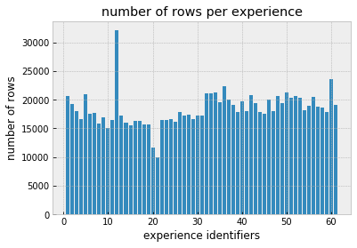

```python
# visualizing row numbers per dataframe

plt.bar(exp_ids,rows_per_df) # ploting the bar plot

plt.xlabel('experience identifiers') # Set X axis info
plt.ylabel('number of rows') # Set Y axis info
plt.title('number of rows per experience') # Set the title of the bar plot
plt.show() # Show the figure
```

- **II.1.2. Number of useful rows per experience**

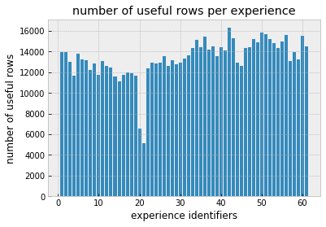

```python
# visualizing useful rows per dataframe
plt.bar(exp_ids,useful_rows_per_df) # ploting the bar plot
plt.xlabel('experience identifiers') # Set X axis info
plt.ylabel('number of useful rows') # Set y axis info
plt.title('number of useful rows per experience') # Set the title of the figure
plt.show() # show the figure
```

- **Number of Rows per activity and Mean time per activity**
- **step 0: Detrimining Number of rows and Mean time per each activity**

```python
# A list will contain number of rows per activity
rows_per_activity=[]

# a list will contain the number of times each activity was performed in the protocol of all experiences
count_act=[]

for i in range(1,13):# iterating over activity ids
    # a dataframe contains start and end labels for all experiences while users were performing the same activity
    start_end_df =Labels_Data_Frame[Labels_Data_Frame['activity_number_ID']==i][['Label_start_point','Label_end_point']]

    # add to the list the number of times this activity was performed in all experiences
    count_act.append(len(start_end_df))

    # start_sum is the sum of all start_label values in start_end_df
    # end_sum is the sum of all end_label values in start_end_df
    start_sum,end_sum=start_end_df.sum()

    # number of rows related to the activity
    number_of_rows=end_sum-start_sum+len(start_end_df)

    # storing number of rows in a list
    rows_per_activity.append(number_of_rows)


# mean duration in seconds of each activity:
time_per_activity=[rows_per_activity[i]/(float(50)*count_act[i]) for i in range(len(rows_per_activity))]

# activity ids from 1 to 12
activity_ids=[i for i in range(1,13)]
```

- **II.1.3 Number of rows per activity:**
  - In this visualzition we calculate the number of rows per activity using all experiences.

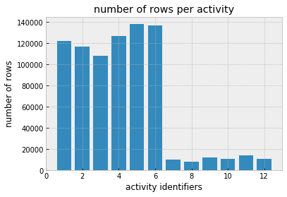

```python
# visualizing the number of rows per activity
plt.bar(activity_ids,rows_per_activity) # plot bar's figure
plt.xlabel('activity identifiers') # Set x axis info
plt.ylabel('number of rows') # Set y axis info
plt.title('number of rows per activity') # set the figure's title
plt.show() # showing the figure
```

- **II.1.4. Mean time per activity**

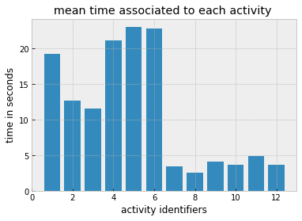

```python
plt.bar(activity_ids,time_per_activity)# plot bar's figure
plt.xlabel('activity identifiers') # Set x axis info
plt.ylabel('time in seconds') # Set y axis info
plt.title('mean time associated to each activity ') # Set the figure's title
plt.show() # showing the figure
```

- **II.1.5. Discussion**
- **Return Back to General visualizations**
- **Return Back to DataExploration**
- **Return Back to the Beginning**

## II.2. Detailed Visualizations

```python
# Two full samples:
sample01_01 = raw_dic['exp01_user01'] # acc and gyro signals of exp 01 user 01
sample47_23 = raw_dic['exp47_user23'] # acc and gyro signals of exp 47 user 23
```

### II.2.1. Define *visualize_triaxial_signals* (visualization function)

```python
sampling_freq=50 # 50 Hz(hertz) is sampling frequency: the number of captured values of each axial signal per second.



def visualize_triaxial_signals(data_frame,exp_id,act,sig_type,width,height):

    #################################### INPUTS ####################################################################
    # inputs: Data_frame: Data frame contains acc and gyro signals                                                 #
    #         exp_id: integer from 1 to 61 (the experience identifier)                                             #
    #         width: integer the width of the figure                                                               #
    #         height: integer the height of the figure                                                             #
    #         sig_type: string  'acc' to visualize 3-axial acceleration signals or 'gyro' for 3-axial gyro signals #
    #         act: possible values: string: 'all' (to visualize full signals) ,                                    #
    #              or integer from 1 to 12 to specify the activity id to be visualized                             #
    #                                                                                                              #
    #              if act is from 1 to 6 it will skip the first 250 rows(first 5 seconds) from                     #
    #              the starting point of the activity and will visualize the next 400 rows (next 8 seconds)        #
    #              if act is between 7 and 12  the function will visualize all rows(full duration) of the activity.#
    #################################################################################################################


    keys=sorted(raw_dic.keys()) # list contains 'expXX_userYY' sorted from 1 to 61
    key=keys[exp_id-1] # the key associated to exp_id (experience)
    exp_id=str(exp_id)
    user_id=key[-2:] # the user id associated to this experience in string format

    if act=='all': # to visualize full signal
        # selecting all rows in the dataframe to be visualized , the dataframe stored in raw_dic and has the same key
        data_df=data_frame
    else:# act is an integer from 1 to 12 (id of the activity to be visualized )
        # Select rows in labels file having the same exp_Id and user_Id mentioned above + the activity id (act)
        # selecting the first result in the search made in labels file
        # and select the start point and end point of this row related to this activity Id (act)
        start_point,end_point=Labels_Data_Frame[
                             (Labels_Data_Frame["experiment_number_ID"]==int(exp_id))&
                             (Labels_Data_Frame["user_number_ID"]==int(user_id))&
                             (Labels_Data_Frame["activity_number_ID"]==act)

                            ][['Label_start_point','Label_end_point']].iloc[0]

        if int(act) in [1,2,3,4,5,6]:# if the activity to be visualed is from 1 to 6 (basic activity)
            # skip the first 250 rows(5 second)
            start_point=start_point+250

            # set the end point at distance of 400 rows (8seconds) from the start_point
            end_point=start_point+400


        # select the 8 seconds shifted by 5 seconds if act between 1 and 6
        # if act is between 7 and 12 select the full duration of the first result(row)
        data_df=data_frame[start_point:end_point]

    ##################################

    columns=data_df.columns # a list contain all column names of the  (6 columns in total)

    if sig_type=='acc':# if the columns to be visualized are acceleration columns

        # acceleration columns are the first 3 columns acc_X, acc_Y and acc_Z
        X_component=data_df[columns[0]] # copy acc_X
        Y_component=data_df[columns[1]] # copy acc_Y
        Z_component=data_df[columns[2]] # copy acc_Z

        # accelerations legends
        legend_X='acc_X'
        legend_Y='acc_Y'
        legend_Z='acc_Z'

        # the figure y axis info
        figure_Ylabel='Acceleration in 1g'

        # select the right title in each case

        if act=='all':
            title="acceleration signals for all activities performed by user "+ user_id +' in experience '+exp_id

        elif act in [1,2,3,4,5,6,7,8,9,10,11,12]:
            title="acceleration signals of experience "+ exp_id+" while user "+ user_id +' was performing activity: '+str(act)+ '('+AL[act]+')'

    elif sig_type=='gyro':# if the columns to be visualized are gyro columns

        # gyro columns are the last 3 columns gyro_X, gyro_Y and gyro_Z
        X_component=data_df[columns[3]] # copy gyro_X
        Y_component=data_df[columns[4]] # copy gyro_Y
        Z_component=data_df[columns[5]] # copy gyro_Z

        # gyro signals legends
        legend_X='gyro_X'
        legend_Y='gyro_Y'
        legend_Z='gyro_Z'

        #the figure y axis info
        figure_Ylabel='Angular Velocity in radian per second [rad/s]'

        # select the right title in each case
        if act=='all':
            title="gyroscope signals for all activities performed by user "+ user_id +' in experience '+exp_id
        elif act in [1,2,3,4,5,6,7,8,9,10,11,12]:
            title="gyroscope signals of experience "+ exp_id+" while user "+ user_id +' was performing activity: '+str(act)+ '('+AL[act]+')'

    # chosing colors : red for X component blue for Y component and green for Z component
    colors=['r','b','g']
    len_df=len(data_df) # number of rows in this dataframe to be visualized(depends on 'act' variable)

    # converting row numbers into time duration (the duration between two rows is 1/50=0.02 second)
    time=[1/float(sampling_freq) *j for j in range(len_df)]

    # Define the figure and setting dimensions width and height
    fig = plt.figure(figsize=(width,height))

    # ploting each signal component
    _ =plt.plot(time,X_component,color='r',label=legend_X)
    _ =plt.plot(time,Y_component,color='b',label=legend_Y)
    _ =plt.plot(time,Z_component,color='g',label=legend_Z)

    # Set the figure info defined earlier
    _ = plt.ylabel(figure_Ylabel) # set Y axis info
    _ = plt.xlabel('Time in seconds (s)') # Set X axis info (same label in all cases)
    _ = plt.title(title) # Set the title of the figure

    # localise the figure's legends
    _ = plt.legend(loc="upper left")# upper left corner

    # showing the figure
    plt.show()
```

### II.2.2. Visualize acc and gyro signals for both samples

- **1.** Visualzing acceleration signals for all activities of experience 01

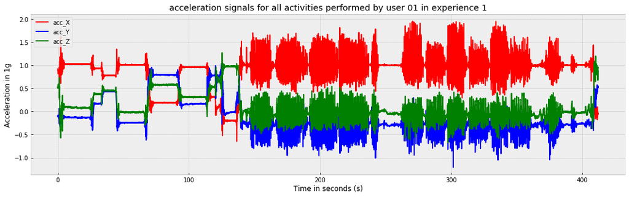

```python
################# plotting acc signals for the first sample ######################
# figure parameters : width=18 height=5
# exp_id=1


#                          DataFrame  , exp_Id, act , sig_type  ,Width,height
visualize_triaxial_signals(sample01_01,   1   ,'all',    'acc'  ,  18 ,  5   )
# sig_type='acc' to visulize acceleration signals
# act='all' to visualize full duration of the dataframe
```

- **2.** Visualzing gyroscope signals for all activities of experience 01

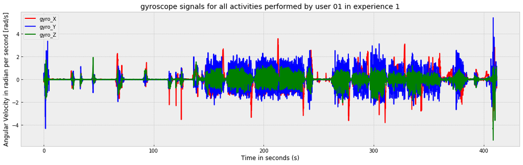

```python
################# plotting gyro signals for the first sample ######################
# figure parameters : width=18 height=5
# exp_id=1
# act='all' to visualize full duration of the dataframe
visualize_triaxial_signals(sample01_01,1,'all','gyro',18,5) # sig_type='gyro' to visualize gyro signals
```

- **3.** Visualzing acceleration signals for all activities of experience 47

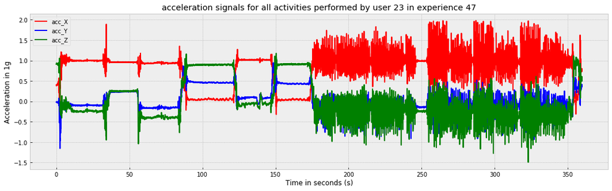

```python
################# plotting acc signals for the second sample ######################
# figure parameters : width=18 height=5
# exp_id=47 user_id=23
# act='all' to visualize full duration of the dataframe
visualize_triaxial_signals(sample47_23,47,'all','acc',18,5) # sig_type='acc' to visulize acceleration signals
```

- **4.** Visualzing gyroscope signals for all activities of experience 47

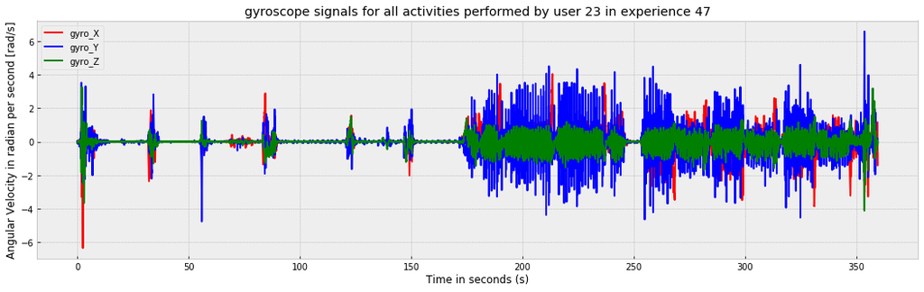

```python
################# plotting gyro signals for the second sample ######################
# figure parameters : width=18 height=5
# exp_id=47 user_id=23
# act='all' to visualize full duration of the dataframe
visualize_triaxial_signals(sample47_23,47,'all','gyro',18,5) # sig_type='gyro' to visualize gyro signals
```

### Discussion

### II.2.3. Define a look up function to explore labels file

- The look up function generates start and end labels points of activity ID in a dataframe **expXX_userYY**

```python
########################FUNCTION: look_up(exp_ID,user_ID,activity_ID)#########################


def look_up(exp_ID,activity_ID):
    ######################################################################################
    # Inputs:                                                                            #
    #   exp_ID  : integer , the experiment Identifier from 1 to 61 (61 included)         #
    #                                                                                    #
    #   activity_ID: integer  the activity Identifier from 1 to 12 (12 included)         #
    # Outputs:                                                                           #
    #   dataframe: A pandas Dataframe which is a part of Labels_Data_Frame contains      #
    #             the activity ID ,the start point  and the end point  of this activity  #
    ######################################################################################
    user_ID=int(sorted(raw_dic.keys())[exp_ID -1][-2:])
    # To select rows in labels file of a fixed activity in a fixed experiment
    return Labels_Data_Frame[
                             (Labels_Data_Frame["experiment_number_ID"]==exp_ID)&
                             (Labels_Data_Frame["user_number_ID"]==user_ID)&
                             (Labels_Data_Frame["activity_number_ID"]==activity_ID)

                            ]
```

- **Return Back to Detailed visualizations**
- **Return Back to DataExploration**
- **Return Back to the Beginning**

### II.2.3. Display some rows in labels file using the look up function

```python
for activity_Id in range(1,13):# iterating throw activity ids from 1 to 12
    # expID=47
    # It returns all Label_start_point and Label_end_point of this (activityID,expID)
    print('Activity number '+str(activity_Id))
    display(look_up(47,activity_Id)) # display the results of each search
```

```
Activity number 1
```

|  | experiment_number_ID | user_number_ID | activity_number_ID | Label_start_point | Label_end_point |
| --- | --- | --- | --- | --- | --- |
| 926 | 47 | 23 | 1 | 9607 | 10673 |
| 927 | 47 | 23 | 1 | 10809 | 11815 |

```
Activity number 2
```

|  | experiment_number_ID | user_number_ID | activity_number_ID | Label_start_point | Label_end_point |
| --- | --- | --- | --- | --- | --- |
| 929 | 47 | 23 | 2 | 13522 | 14142 |
| 931 | 47 | 23 | 2 | 15055 | 15729 |
| 933 | 47 | 23 | 2 | 16692 | 17355 |

```
Activity number 3
```

|  | experiment_number_ID | user_number_ID | activity_number_ID | Label_start_point | Label_end_point |
| --- | --- | --- | --- | --- | --- |
| 928 | 47 | 23 | 3 | 12723 | 13402 |
| 930 | 47 | 23 | 3 | 14294 | 14952 |
| 932 | 47 | 23 | 3 | 15892 | 16556 |

```
Activity number 4
```

|  | experiment_number_ID | user_number_ID | activity_number_ID | Label_start_point | Label_end_point |
| --- | --- | --- | --- | --- | --- |
| 916 | 47 | 23 | 4 | 1820 | 2774 |
| 922 | 47 | 23 | 4 | 6213 | 7340 |

```
Activity number 5
```

|  | experiment_number_ID | user_number_ID | activity_number_ID | Label_start_point | Label_end_point |
| --- | --- | --- | --- | --- | --- |
| 914 | 47 | 23 | 5 | 424 | 1597 |
| 918 | 47 | 23 | 5 | 2925 | 4223 |

```
Activity number 6
```

|  | experiment_number_ID | user_number_ID | activity_number_ID | Label_start_point | Label_end_point |
| --- | --- | --- | --- | --- | --- |
| 920 | 47 | 23 | 6 | 4484 | 6041 |
| 924 | 47 | 23 | 6 | 7560 | 8660 |

```
Activity number 7
```

|  | experiment_number_ID | user_number_ID | activity_number_ID | Label_start_point | Label_end_point |
| --- | --- | --- | --- | --- | --- |
| 915 | 47 | 23 | 7 | 1598 | 1819 |

```
Activity number 8
```

|  | experiment_number_ID | user_number_ID | activity_number_ID | Label_start_point | Label_end_point |
| --- | --- | --- | --- | --- | --- |
| 917 | 47 | 23 | 8 | 2775 | 2924 |

```
Activity number 9
```

|  | experiment_number_ID | user_number_ID | activity_number_ID | Label_start_point | Label_end_point |
| --- | --- | --- | --- | --- | --- |
| 923 | 47 | 23 | 9 | 7341 | 7559 |

```
Activity number 10
```

|  | experiment_number_ID | user_number_ID | activity_number_ID | Label_start_point | Label_end_point |
| --- | --- | --- | --- | --- | --- |
| 921 | 47 | 23 | 10 | 6042 | 6212 |

```
Activity number 11
```

|  | experiment_number_ID | user_number_ID | activity_number_ID | Label_start_point | Label_end_point |
| --- | --- | --- | --- | --- | --- |
| 919 | 47 | 23 | 11 | 4224 | 4483 |

```
Activity number 12
```

|  | experiment_number_ID | user_number_ID | activity_number_ID | Label_start_point | Label_end_point |
| --- | --- | --- | --- | --- | --- |
| 925 | 47 | 23 | 12 | 8661 | 8821 |

#### Discussion

- From the results above it appears that:
  - 2 dynamic activities were performed 3 times (activity 02 : **Walking up stairs**, activity 03: **Walking down stairs**)
  - 4 basic activities (1 dynamic and 3 static) were performed 2 times ( activtity 01: **Walking**,activity 04:**Sitting**, activity 05:**Standing**,activity 06:**Liying**)
  - All postural transitions activity ids from 7 to 12 were performed 1 times each.

### II.2.5. Visualize signals related to *Basic Activities* for sample N° 2

- In this detailed visualization i choosed to :
  - skip the first 5 seconds (the first 250 row) after the Label_start_point and visualize the next 8 seconds (400 row) of each basic activity using the first search results in each table above.
  - For postural transitions i decide to visualize all their full duration.

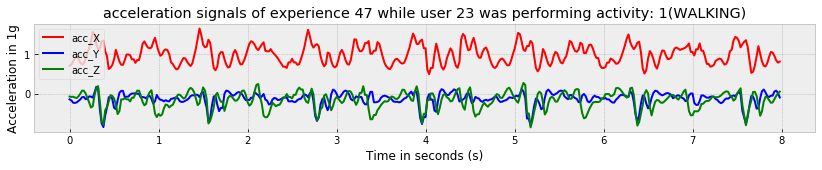

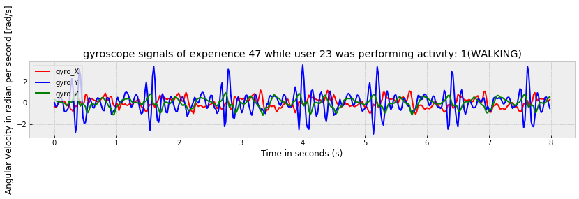

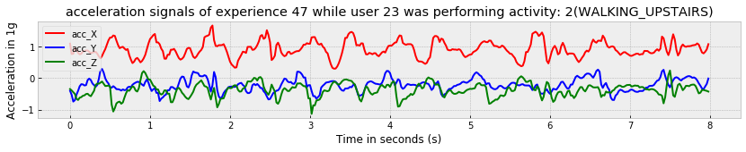

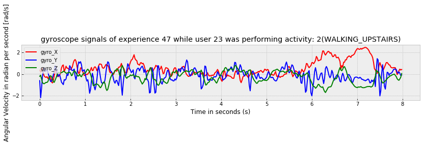

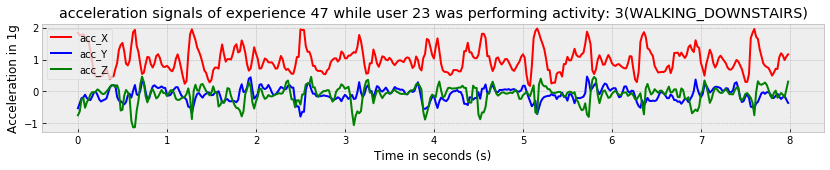

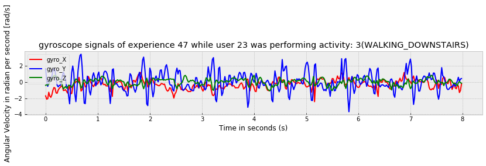

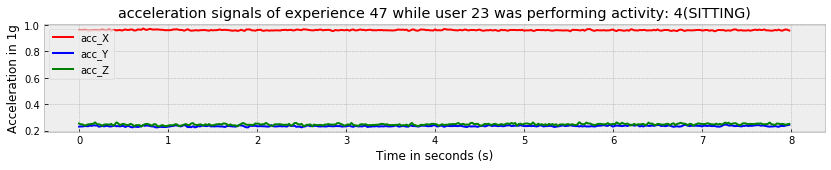

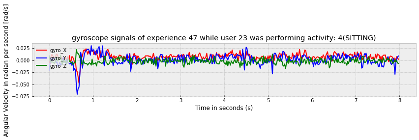

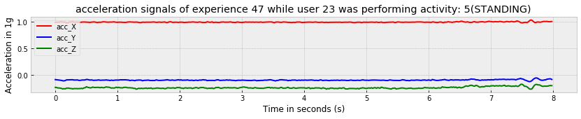

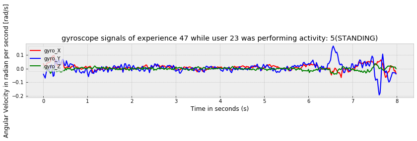

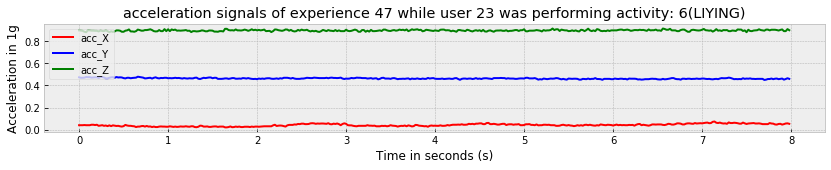

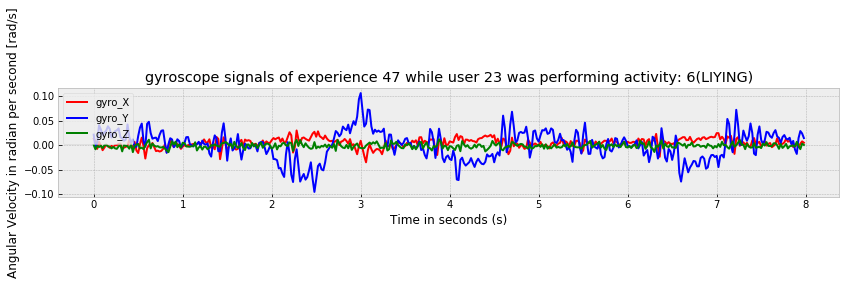

```python
# visualize Basic activities from 1 to 6
for act in range(1,7): # Iterating throw each activity Id from 1 to 6
    visualize_triaxial_signals(sample47_23,47,act,'acc',14,2) # visualize acc signals related to this activity
    visualize_triaxial_signals(sample47_23,47,act,'gyro',14,2) # visualize gyro signals reated to this activity
```

#### Discussion:

### Visualize signals related to *Postural Transitions* for sample N° 2

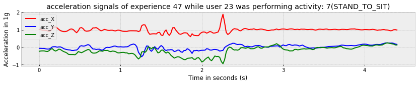

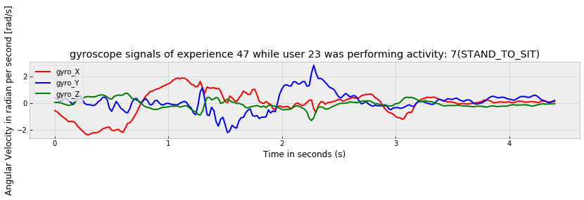

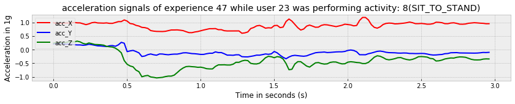

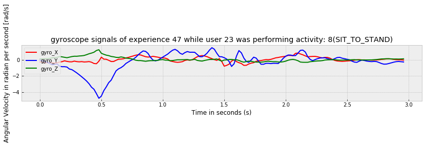

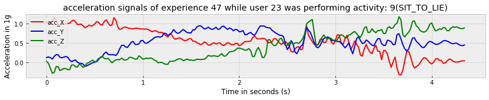

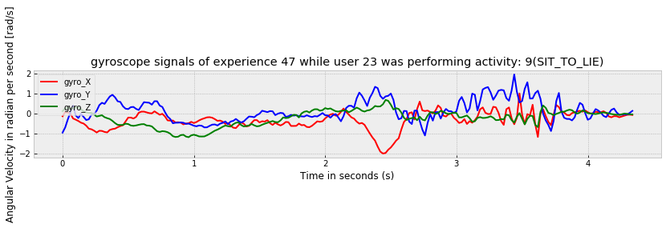

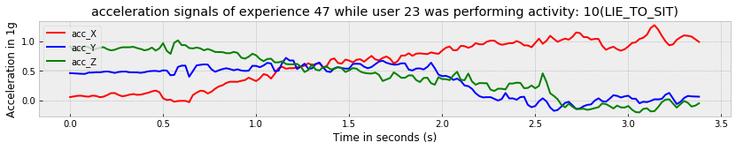

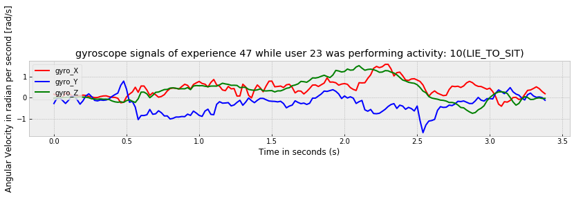

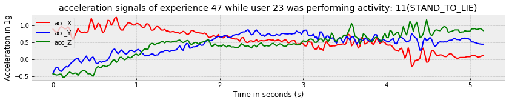

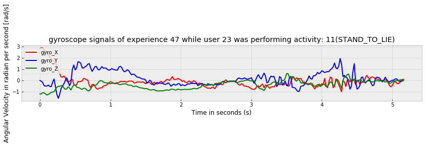

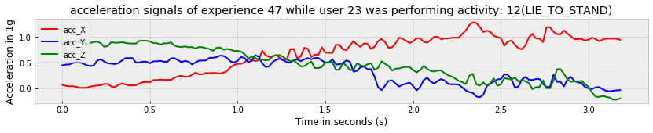

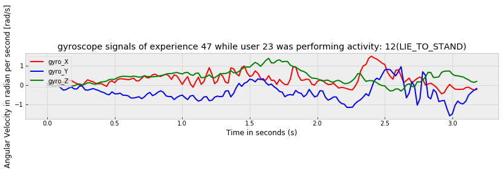

```python
# visualize postural transitions (act_id from 7 to 12)
for activity_Id in range(7,13): # iterating throw each activity Ids from 7 to 12
    visualize_triaxial_signals(sample47_23,47,activity_Id,'acc',14,2) # visualize acc signals related to this activity
    visualize_triaxial_signals(sample47_23,47,activity_Id,'gyro',14,2) # visualize gyro signals related to this activity
```

#### Discussion

- **Return Back to Detailed visualizations**
- **Return Back to DataExploration**
- **Return Back to the Beginning**